# R Notebook

This notebook contains a record of my data cleaning and manipulation of my PATT 2016-7 faunal analysis.

# Loading base data

This section out the basic cleaning and organisation of my Tlajinga data using the 2016 and 2017 data cleaning excel files. Changes to the spreadsheets should be made to these original files. Most of the species changes I carried out in the spreadsheets themselves. I used this code to create a new master dataset for future analysis.

```r
rm(list = ls())
```

```r
library(dplyr)
```

```r
library(dplyr)
```

```r
#This code creates a list of the unique elements in the R_El column.
uni_el<-unique(d1$R_El)
#I used this list to code each to a particular standardised element
```

```r
#This code creates a list of the unique elements in the R_El column in the second dataset and adds them to the prior dataset
uni_el2<-unique(d2$R_El)
uni_merg<-c(as.character(uni_el), as.character(uni_el2))
uni_all<-unique(uni_merg)
```

```r
#This code creates a new column for standardized elements and uses the look up list to provide the standardised element for that specimen.
d1$New_El<-el_list$Standard[match(d1$R_El, el_list$Orig)]
d2$New_El<-el_list$Standard[match(d2$R_El, el_list$Orig)]
```

```r
write.csv(d1, file= "2017_new_element.csv", append=FALSE)
```

```
attempt to set 'append' ignored
```

```r
write.csv(d2, file= "2016_new_element.csv")
```

## CLEANING PORTION DATA

```r
uni_por2<-unique(d2$R_portion)
```

I ended up cleaning those up in the original spreadsheet.

Now I will put the datasets back together and clean the species names and set the groupings by type.

```r
temp1<-select(d1, -Portion, -Element.info, -Comments)
temp2<-select(d2, -Portion, -Comments)
names(temp1)[45]<-"Details"
names(temp2)[45]<-"Details"
names(temp2)[20]<-"R_Portion"
names(temp1)
```

```
 [1] "ID"                                "YEAR"                              "Volume"                            "Lote"
 [5] "Operacion"                         "Unidad"                            "EL."                               "Investigator"
 [9] "Fecha"                             "Class"                             "Category"                          "Genus"
[13] "Species"                           "Name"                              "CF"                                "R_El"
[17] "R_info"                            "Side"                              "Completeness..0.frag..1.complete." "R_Portion"
[21] "Fragmentation"                     "NISP"                              "MNE"                               "Estimate.AGE"
[25] "Fusion.wear"                       "Proximal"                          "Shaft"                             "Distal"
[29] "Taphonomy"                         "Photographed"                      "Bird.to.confirm.ID"                "Additional.analysis"
[33] "Quality.of.heat.fire.exposure"     "X..Charred"                        "X..Heat.exposed"                   "Carnivore"
[37] "Rodent"                            "Worked"                            "Butchery"                          "Weathering"
[41] "Other"                             "Calcined"                          "Measurements"                      "Location.of.measurement"
[45] "Details"                           "New_El"
```

```r
names(temp2)
```

```
 [1] "ID"                                "YEAR"                              "Volume"                            "Lote"
 [5] "Operacion"                         "Unidad"                            "EL."                               "Investigator"
 [9] "Fecha"                             "Class"                             "Category"                          "Genus"
[13] "Species"                           "Name"                              "CF"                                "R_El"
[17] "R_info"                            "Side"                              "Completeness..0.frag..1.complete." "R_Portion"
[21] "Fragmentation"                     "NISP"                              "MNE"                               "Estimate.AGE"
[25] "Fusion.wear"                       "Proximal"                          "Shaft"                             "Distal"
[29] "Taphonomy"                         "Photographed"                      "Bird.to.confirm.ID"                "Additional.analysis"
[33] "Quality.of.heat.fire.exposure"     "X..Charred"                        "X..Heat.exposed"                   "Carnivore"
[37] "Rodent"                            "Worked"                            "Butchery"                          "Weathering"
[41] "Other"                             "Calcined"                          "Measurements"                      "Location.of.measurement"
[45] "Details"                           "New_El"
```

HEre I will look for unique names in the Name coloumn

```r
unique(Tla_1$Name)
```

Here I am selecting a subset so I can identify double-ups in species naming and change for consistency in the spreadsheet.

```r
sp.<-select(Tla_1, Class, Category, Genus, Species, Name)
uni_sp<-(unique(sp.))
```

Here I am looking at the details and structure of the dataset I created

```r
names(Tla_1)
str(Tla_1)
```

Renaming final Element columns

```r
library(dplyr)
Tla_1$R_El<-Tla_1$New_El
Tla_1<-select(Tla_1, -New_El)
```

## Adding in confidence value for species IDS

```r
lconf<-read.csv("low_confidence_ID.csv")
Tla_1$lconf<-NA
for (i in 1:nrow(Tla_1))
if ((Tla_1$Name[i] %in% lconf[,1])==FALSE){Tla_1$lconf[i]<-"0"} else {Tla_1$lconf[i]<-"1"}
```

# Creating list of body parts from Elements

```r
elist<-unique(Tla_1$R_El)
```

```r
body<-read.csv("Bodypart.csv")
```

```r
Tla_1$R_El<-Tla_1$New_El
Tla_1<-select(Tla_1, -New_El)
write.csv(Tla_1, file= "Tlajinga_cleaned_1_25_18.csv")
```

## Final spreadsheet for export:

```r
write.csv(Tla_1, file= "Tlajinga_cleaned_1_25_18.csv")
```

Randomly select 10 bags for ZooMS

```r
runif(10, 1,283)
```

# Data subsets

Here I am learning use the NISP count data to summarise my new dataset

First I am editing some category details to make a better summary.

```r
Tla_1$Category<-if_else(Tla_1$Category=="General", Tla_1$Name, Tla_1$Category)
Tla_1$Category<-if_else(Tla_1$Category=="cf. Guajolote", "Bird", Tla_1$Category)
Tla_1<-filter(Tla_1, !Category=="") #here I am removing the fossil and empty bag from Tla_1 dataset
```

This code writes a subset of the columns of Tla_1

```r
Tla_2<-select (Tla_1, ID, Operacion, Unidad, Lote, EL., Class, Category, Genus, Species, Name, NISP) #i've now included ID here so I can link it back to the original spreadsheet.
```

## GIS datasets

```r
library(reshape2)
```

Here I am creating subsets of the data for GIS. Note that the rowSUMs needs to be updated when the selected categories change. This will overwrite the file saved to the WD. Note that for YEAR to be included in GIS, it needs to be a different name:i.e. names(Op_17)[2]<-“analy_year”

```r
temp<-select (Tla_1, ID, Operacion, Unidad, Lote, EL., Class, Category, Genus, Species, Name, NISP) #i've now included ID here so I can link it back to the original spreadsheet.
Op_17<-filter(temp, Operacion=="17")
melt17<-melt(Op_17, measure.vars = "NISP")%>%
dcast(Operacion+Unidad~Class+Name, sum)%>%
mutate(Total_Row = rowSums(.[3:65]))
names(melt17)<-gsub("[[:punct:][:space:]]", "", names(melt17))
```

```r
Op_18<-filter(temp, Operacion=="18")
melt18<-melt(Op_18, measure.vars = "NISP")%>%
dcast(Operacion+Unidad~Class+Name, sum)%>%
mutate(Total_Row = rowSums(.[3:93]))
names(melt18)<-gsub("[[:punct:][:space:]]", "", names(melt18))
write.csv(melt18, file= "Op_18_GIS.csv")
```

# Learning stargazer and plotly.

Here, I found the NISP did not sum appropriately, and later learnt melt to clean my data further to fix this. This code should be check carefully when applied to make sure the summary statistics are correct Creating variable summary tables and pie charts

```r
library(plotly)
```

```r
temp<-filter(Tla_2, !Category=="Human") #add filters here if necessary
by_group<-temp%>%group_by(Operacion, Name) #simply changes group_by to edit table and piechart
t<-summarise(by_group, "NISP"=sum(NISP))
sum(t$NISP)#check that this equals total NISP for spreadsheet, currently 3360
t
plot_ly(t, labels = (t)[[1]], values = ~NISP, type = 'pie', textposition = 'inside', # note that the values must be directly attributed to the variable because it doesn't seem to sum.
        textinfo = 'label+percent')
```

```r
names(t)[1]
```

```r
by_class<-Tla_2%>%group_by(Class, Category, Name)
```

```r
sp_table<-summarise(by_class, "NISP"=sum(NISP))#I had a lot of trouble with this, only got it to work by adding caode into the data input line to have strings as factors FALSE
sp_table
sum(sp_table$NISP)
```

```r
library(plotly)
```

Making a pie chart of the table above

```r
p <- plot_ly(sp_table, labels = ~Name, values = ~NISP, type = 'pie', textposition = 'inside', # note that the values must be directly attributed to the variable because it doesn't seem to sum.
        textinfo = 'label+percent')
```

```r
p
```

Code for stargazer for pulication quality tables

```r
library(stargazer)
sp_table<-summarise(by_class, "NISP"=sum(NISP))#I had a lot of trouble with this, only got it to work by adding caode into the data input line to have strings as factors FALSE
stargazer(sp_table, type="text", summary=FALSE)
```

# Adding chronology to the dataset

I’m going to use the datasets above to create a new melt for each LOTE to join with the new chronology groups I created in excel and see if I can identify some basic patterns over time.

```r
chron17<-read.csv("17_Chro_join.csv", stringsAsFactors = FALSE)
```

```r
library(reshape2)
library(dplyr)
```

```r
temp<-select (Tla_1, ID, Operacion, Unidad, Lote, EL., Class, Category, Genus, Species, Name, NISP) #i've now included ID here so I can link it back to the original spreadsheet.
Op_17<-filter(temp, Operacion=="17")
melt17<-melt(Op_17, measure.vars = "NISP")%>%
dcast(Operacion+Unidad+Lote~Category, sum)
```

```r
melt17<-mutate(melt17, Total_Row = rowSums(melt17[4:23]))
names(melt17)<-gsub("[[:punct:][:space:]]", "", names(melt17))
melt17$phase<-chron17$Chronology.group[match(melt17$Lote, chron17$Lote)]
write.csv(melt17, file= "17_chron.csv")
```

```r
melt17<-melt17%>%group_by(as.factor(phase))
```

```r
temp_sum<-summarise(melt17, sum(Bird), sum(Fish), sum(Mammal), sum(Reptile))
```

```r
str(temp_sum)
```

# Creating list of body parts from Elements

```r
elist<-unique(Tla_1$R_El)
```

```r
body<-read.csv("Bodypart.csv")
```

```r
Tla_1$body<-body$Body.part[match(Tla_1$R_El, body$Element)]
```

```r
library(dplyr)
Tla_1%>%filter(Name=="White-tailed deer")%>%group_by(body)%>%summarise(sum(NISP))
```

| body | sum(NISP) |
| --- | --- |
|  | 13 |
| Chest | 3 |
| Feet | 16 |
| Forelimb | 19 |
| Frag | 1 |
| Head | 16 |
| Hindlimb | 17 |
| Spine | 18 |

```r
Tla_1%>%filter(Category=="Artiodactyla")%>%group_by(body)%>%summarise(sum(NISP))
```

| body | sum(NISP) |
| --- | --- |
|  | 14 |
| Chest | 56 |
| Feet | 31 |
| Forelimb | 35 |
| Frag | 1 |
| Head | 37 |
| Hindlimb | 24 |
| Shaft | 4 |
| Spine | 46 |

```r
Tla_1%>%filter(Category=="Artiodactyla", !Name=="White-tailed deer")%>%group_by(body)%>%summarise(sum(NISP))
```

| body | sum(NISP) |
| --- | --- |
|  | 1 |
| Chest | 53 |
| Feet | 15 |
| Forelimb | 16 |
| Head | 21 |
| Hindlimb | 7 |
| Shaft | 4 |
| Spine | 28 |

# Scatter plot of head-limb relationship

```r
library(dplyr)
library(reshape2)
temp<-select (Tla_1, ID, Operacion, Category, Name, NISP, body)
body_melt<-melt(temp, measure.vars = "NISP")
```

```r
body_g<-dcast(body_melt, Operacion+Category~body, sum)
```

```r
body_g$limb<-body_g$Forelimb+body_g$Hindlimb
```

```r
g<-ggplot(filter(body_g, (Category=="Anseriformes"| Category=="Artiodactyla"|Category=="Carnivora"|Category== "Leporidae") & !Operacion=="SOTD"), aes(Head, limb))
```

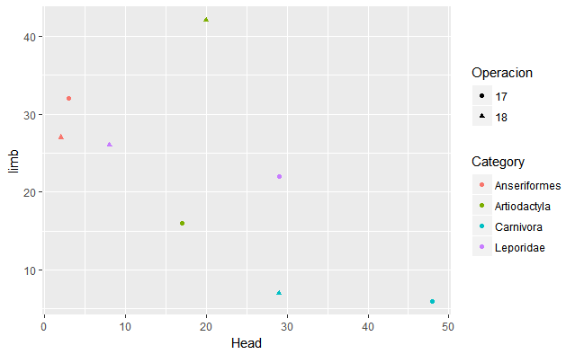

```r
g+geom_point(aes(color=Category, shape=Operacion))
```

Bar graphs of these

```r
cat_bod<-aggregate(NISP~Category+body, data=Tla_1, sum)
```

```r
g<-ggplot(filter(Tla_1, (Category=="Artiodactyla"|Category=="Carnivora"|Category=="Leporidae") & !Operacion=="SOTD" & (body=="Chest"|body=="Feet"|body=="Forelimb"|body=="Head"|body=="Hindlimb"|body=="Spine")), aes(Category, NISP))
```

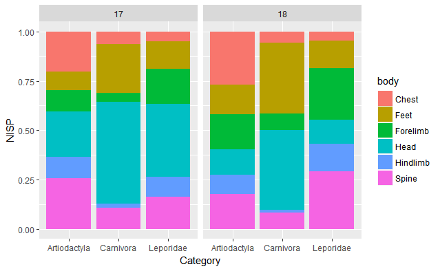

```r
g+geom_bar(aes(fill=body), position="fill", stat="identity")+facet_grid(.~Operacion)
```

# bar graph comparing body parts to standards

```r
stan<-read.csv("body_standard.csv")
```

```r
stan<-melt(stan)
```

```r
stan$Operacion<-"standard"
names(stan)[3]<-"NISP"
names(stan)[2]<-"Category"
```

creating the joint dataset

```r
temp<-select(Tla_1, Operacion, Category, body, NISP)
temp<-filter(temp, (Category=="Artiodactyla"|Category=="Carnivora"|Category=="Leporidae") & !Operacion=="SOTD" & (body=="Chest"|body=="Feet"|body=="Forelimb"|body=="Head"|body=="Hindlimb"|body=="Spine"))
body_test<-rbind(temp, stan)
```

creating the graph

```r
g<-ggplot(body_test, aes(Operacion, NISP))
```

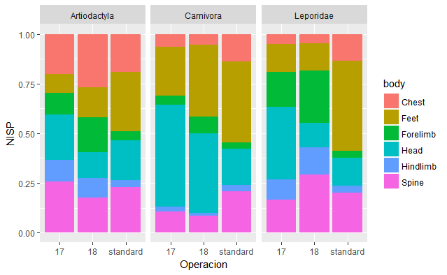

```r
g+geom_bar(aes(fill=body), position="fill", stat="identity")+facet_grid(.~Category)
```

# scatter comparison of above

```r
body_test2<-dcast(body_test, Category+body~Operacion, sum)
```

```r
names(body_test2)[3]<-"op17"
names(body_test2)[4]<-"op18"
```

```r
body_test2$tla<-body_test2$op17+body_test2$op18
```

```r
g<-ggplot(body_test2, aes(standard, tla))
```

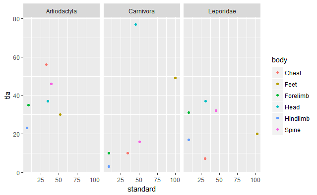

```r
g+geom_point(aes(color=body))+facet_grid(.~Category)
```

```r
lm(standard~tla, body_test2)
```

```
Call:
lm(formula = standard ~ tla, data = body_test2)

Coefficients:
(Intercept)          tla
    23.1480       0.4241
```

# Chi-sq analysis of the above

```r
temp<-filter(body_test2, Category=="Leporidae")
tla<-temp$tla
row.names(temp)<- temp$body
P<-prop.table(temp$standard)
```

```r
P2<-c(0.18965517, 0.29885057, 0.04597701, 0.20114943, 0.03448276, 0.22988506)
```

```r
P
```

[output not shown]

```r
P2
```

```
[1] 0.18965517 0.29885057 0.04597701 0.20114943 0.03448276 0.22988506
```

```r
chi<-chisq.test(x=temp$tla, p=P, simulate.p.value = TRUE, B=100)
```

```r
chi
```

```
    Chi-squared test for given probabilities with simulated p-value (based on 100 replicates)

data:  temp$tla
X-squared = 211.79, df = NA, p-value = 0.009901
```

```r
chi$observed
```

```
[1]  7 20 31 37 17 32
```

```r
round(chi$expected,2)
```

```
[1] 19.29 65.57  5.14 19.93  5.14 28.93
```

```r
round(chi$residuals, 2)
```

```
[1] -2.80 -5.63 11.40  3.82  5.23  0.57
```

# standardizing body parts

```r
body_test2$bodynew<-body_test2$tla/body_test2$standard
```

```r
g<-ggplot(body_test2, aes(Category, bodynew))
```

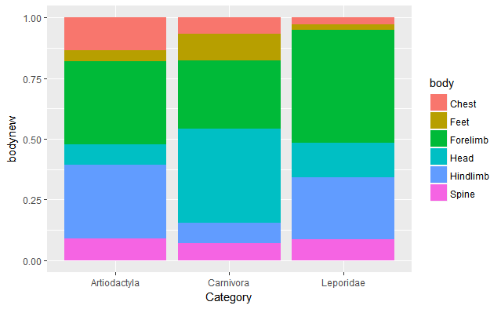

```r
g+geom_bar(aes(fill=body), position="fill", stat="identity")
```

[output not shown]